# Assignment 5: Regularization

Author

Solutions by Dr. Theobold

Loading packages and setting a seed:

````markdown
```{r}
#| label: setup
#| message: false
#| warning: false

library(tidyverse)
library(tidymodels)
library(leaps)
library(rpart.plot)

set.seed(282)
```
````

Load the main dataset, and the validation set:

````markdown
```{r}
#| label: data-load-clean
#| message: false
#| warning: false

genes <- read_csv(here::here("05-Regularization",
                             "Assignment",
                             "data",
                             "genes_cancer_train.csv")
                  )
genes_validation <- read_csv(here::here("05-Regularization",
                             "Assignment",
                             "data",
                             "genes_cancer_validate.csv")
                  )

## Convert response to factor since that is what tidymodels expects
genes <- genes %>%
  mutate(
    cancer = factor(cancer)
  )

genes_validation <- genes_validation %>%
  mutate(
    cancer = factor(cancer)
  )
```
````

## Subsetting Data

For most of this lab (right up until the end), we will use a smaller version of the datasets, so as not to murder your personal computers. We’ll choose a random 100 of the variables:

````markdown
```{r}
#| label: subsetting-data

random_columns <- sample(3:ncol(genes),
                         size = 100)

genes_sub <- genes %>%
  select(1,
         2,
         all_of(random_columns)
         )
```
````

# Part One: Classification Without Regularization

````markdown
```{r}
#| label: genes-recipes

genes_rec_sub <- recipe(cancer ~ ., data = genes_sub) %>%
  update_role(patient, new_role = "id variable")

genes_rec_full <- recipe(cancer ~ ., data = genes) %>%
  update_role(patient, new_role = "id variable")
```
````

#### Q1: Decision Tree

Fit a decision tree to this data. Which genes does it designate as most important for differentiating ALL and AML cancers? How pure are the nodes?

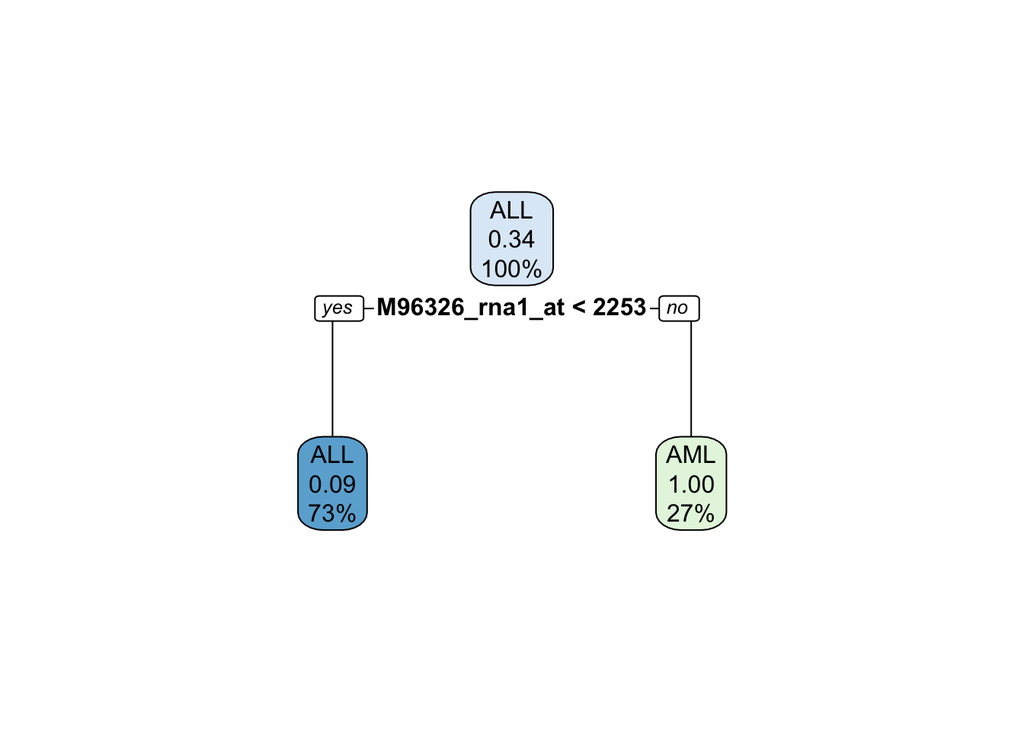

````markdown
```{r}
#| label: decision-tree

tree_spec <- decision_tree() %>%
  set_mode("classification") %>%
  set_engine("rpart")

tree_fit <- workflow() %>%
  add_model(tree_spec) %>%
  add_recipe(genes_rec_sub) %>%
  fit(genes_sub)

tree_fitted <- tree_fit %>%
  extract_fit_parsnip()

rpart.plot(tree_fitted$fit, roundint = FALSE)
```
````

*Based on the decision tree, `M96326_rna1_at` is the main gene that is designated as important for differentiating ALL from AML cancer. The resulting leaves are almost entirely pure, with only 9% of observations in the ALL leaf being misclassified.*

#### Q2: Validation

Use your tree to predict on the validation set. How did it do?

````markdown
```{r}
#| label: tree-validation

genes_validation %>%
  mutate(
    preds = predict(tree_fit, genes_validation)$.pred_class
  ) %>%
  accuracy(truth = cancer, estimate = preds)
```
````

```
# A tibble: 1 × 3
  .metric  .estimator .estimate
  <chr>    <chr>          <dbl>
1 accuracy binary         0.857
```

It did fairly well, correctly classifying the type of cancer 85% of the time. This is about 20% more effective than just guessing ALL every time (since it occurs in 65% of the observations).

````markdown
```{r}
#| label: null-classifier-comparison
genes_sub %>%
  count(cancer) %>%
  mutate(prop = n / sum(n))
```
````

```
# A tibble: 2 × 3
  cancer     n  prop
  <fct>  <int> <dbl>
1 ALL       29 0.659
2 AML       15 0.341
```

#### Q3: Explanation.

When we predict on the validation set, we do *okay*, because the variable is probably somewhat meaningful - but not as perfectly as we might expect, and not as well as we probably could have done with more variables involved.

This is a form of overfitting, even though it doesn’t appear so from the tree. When the model has too many variables to choose from, it can have “too much success” on the training data.

#### Q4: Random Forest

Now fit a Random Forest to the data.

````markdown
```{r}
#| label: random-forest

rf_spec <- rand_forest() %>%
  set_mode("classification") %>%
  set_engine("ranger")

rf_fit <- workflow() %>%
  add_model(rf_spec) %>%
  add_recipe(genes_rec_sub) %>%
  fit(genes_sub)
```
````

#### Q5: Validation

Use your random forest to predict on the validation set. How did it do?

````markdown
```{r}
genes_validation %>%
  mutate(
    cancer = factor(cancer),
    preds = predict(rf_fit, genes_validation)$.pred_class
  ) %>%
  accuracy(truth = cancer, estimate = preds)
```
````

```
# A tibble: 1 × 3
  .metric  .estimator .estimate
  <chr>    <chr>          <dbl>
1 accuracy binary         0.964
```

This is pretty good! Our accuracy improved by 10% from the decision tree and we are now doing over 30% better than the null classifier.

#### Q6: Explanation

How does this method compare to a single decision tree? Give an explanation for the difference in results.

# Part Two: Variable Selection

````markdown
```{r}
#| label: cancer-to-integer

genes_weird_sub <- genes_sub %>%
  mutate(
    cancer = as.integer(
      factor(cancer)
      )
  )
```
````

#### Q7: Stepwise selection.

Use forwards or backwards selection (your choice) to choose the ideal number of variables, up to a maximum of 10. Which genes are chosen?

````markdown
```{r}
#| label: backward-selection
#| cache: true
#| warning: false

models <- regsubsets(cancer ~ ., data = genes_weird_sub,
                     method = "backward",
                     nvmax = 10)

bic_scores <- summary(models)$bic
best_model <- which.min(bic_scores)

vars <- summary(models)$outmat[best_model, ]
best_vars <- names(vars[vars == "*"])
best_vars
```
````

```
 [1] "patient"          "Y10812_at"        "U25182_at"        "L23333_s_at"
 [5] "U22970_rna1_s_at" "M90299_at"        "U28833_at"        "K03431_cds1_at"
 [9] "M76665_at"        "U57623_s_at"
```

#### Q8: LASSO.

Tune a LASSO regression. Identify the largest penalty parameter that doesn’t cause you to lose any prediction accuracy.

````markdown
```{r}
#| label: lambda-grid

lam_grid <- grid_regular(penalty(c(-10, 0),
                                 trans = log2_trans()
                                 ),
                         levels = 10)
```
````

````markdown
```{r}
#| label: lasso-tune
#| cache: true

lass_spec <- logistic_reg(penalty = tune(),
                          mixture = 1
                          ) %>%
  set_mode("classification") %>%
  set_engine("glmnet")

cvs <- vfold_cv(genes_sub, v = 5)

lass_wflow <- workflow() %>%
  add_recipe(genes_rec_sub) %>%
  add_model(lass_spec)

tuning <- lass_wflow %>%
  tune_grid(
    resamples = cvs,
    grid = lam_grid
  )

tuning %>%
  show_best(metric = "accuracy")
```
````

```
# A tibble: 5 × 7
   penalty .metric  .estimator  mean     n std_err .config
     <dbl> <chr>    <chr>      <dbl> <int>   <dbl> <chr>
1 0.0992   accuracy binary     0.867     5  0.0544 Preprocessor1_Model07
2 0.0213   accuracy binary     0.864     5  0.0542 Preprocessor1_Model05
3 0.0459   accuracy binary     0.864     5  0.0542 Preprocessor1_Model06
4 0.000977 accuracy binary     0.842     5  0.0438 Preprocessor1_Model01
5 0.00211  accuracy binary     0.842     5  0.0438 Preprocessor1_Model02
```

The largest penalty with the best accuracy is 0.0992, however lower penalties of 0.0213 and 0.0459 have accuracies that are less than 1% away from the top.

#### Q9: LASSO Variable Selection.

Using the penalty chosen in Q2, fit a final LASSO model on the **full data** (that is, on `genes` not on `genes_sub`). What genes were selected?

````markdown
```{r}
#| label: lasso-variable-selection
#| cache: true

lass_spec_untune <- logistic_reg(penalty = 0.0992,
                                 mixture = 1) %>%
  set_mode("classification") %>%
  set_engine("glmnet")

workflow() %>%
  add_recipe(genes_rec_full) %>%
  add_model(lass_spec_untune) %>%
  fit(genes) %>%
  extract_fit_parsnip() %>%
  tidy() %>%
  filter(estimate != 0) %>%
  select(term)
```
````

```
# A tibble: 14 × 1
   term
   <chr>
 1 (Intercept)
 2 D55696_at
 3 HG1612-HT1612_at
 4 J05243_at
 5 M55150_at
 6 M63138_at
 7 M98539_at
 8 U46499_at
 9 X95735_at
10 Y07604_at
11 Z24727_at
12 M13690_s_at
13 M31211_s_at
14 X85116_rna1_s_at
```

# Part Three: Reducing Variance of Coefficients

#### Q10: Ordinary Logistic Regression

Randomly divide the observations in the dataset (back to `genes_sub`) in half. Fit a logistic regression on the with no penalty term to each half.

Report the estimates for the first five predictors (not the Intercept!). How different were they between the two subsamples of the datset?

````markdown
```{r}
#| label: logistic-regression
#| cache: true

splits <- initial_split(genes_sub, 0.5)
genes_sub_1 <- training(splits)
genes_sub_2 <- testing(splits)

logistic_nopenalty_spec <- logistic_reg() %>%
  set_mode("classification") %>%
  set_engine("glm")
```
````

**Split 1**

````markdown
```{r}
#| label: split1-logistic-results

workflow() %>%
  add_recipe(genes_rec_sub) %>%
  add_model(logistic_nopenalty_spec) %>%
  fit(genes_sub_1) %>%
  extract_fit_parsnip() %>%
  tidy() %>%
  select(term, estimate) %>%
  filter(term != "(Intercept)") %>%
  slice_head(n = 5)
```
````

```
# A tibble: 5 × 2
  term        estimate
  <chr>          <dbl>
1 Y10812_at      0.169
2 Y12556_at     -0.373
3 M37238_s_at   -0.138
4 D25248_at      0.141
5 X06661_at     -1.79
```

**Split 2**

````markdown
```{r}
#| label: split2-logistic-results

workflow() %>%
  add_recipe(genes_rec_sub) %>%
  add_model(logistic_nopenalty_spec) %>%
  fit(genes_sub_2) %>%
  extract_fit_parsnip() %>%
  tidy() %>%
  select(term, estimate) %>%
  filter(term != "(Intercept)") %>%
  slice_head(n = 5)
```
````

```
# A tibble: 5 × 2
  term        estimate
  <chr>          <dbl>
1 Y10812_at     0.143
2 Y12556_at    -0.0703
3 M37238_s_at  -0.0828
4 D25248_at     0.178
5 X06661_at    -0.0930
```

#### Q11: Ridge Regression - Tuning

Tune a logistic regression with ridge penalty on `genes_sub`. Once again, choose the largest penalty that does not noticeably decrease the accuracy.

````markdown
```{r}
#| label: ridge-regression-tune
#| cache: true

ridge_spec <- logistic_reg(penalty = tune(),
                           mixture = 0) %>%
  set_mode("classification") %>%
  set_engine("glmnet")

ridge_wflow <- workflow() %>%
  add_recipe(genes_rec_sub) %>%
  add_model(ridge_spec)

tuning <- ridge_wflow %>%
  tune_grid(
    resamples = cvs,
    grid = lam_grid
  )

tuning %>%
  show_best(metric = "accuracy")
```
````

```
# A tibble: 5 × 7
   penalty .metric  .estimator  mean     n std_err .config
     <dbl> <chr>    <chr>      <dbl> <int>   <dbl> <chr>
1 0.000977 accuracy binary     0.817     5  0.0299 Preprocessor1_Model01
2 0.00211  accuracy binary     0.817     5  0.0299 Preprocessor1_Model02
3 0.00456  accuracy binary     0.817     5  0.0299 Preprocessor1_Model03
4 0.00984  accuracy binary     0.817     5  0.0299 Preprocessor1_Model04
5 0.0213   accuracy binary     0.817     5  0.0299 Preprocessor1_Model05
```

For ridge regression, a penalty of 0.0213 is the largest with the same predictive accuracy.

#### Q12: Comparison

Fit a logistic regression with the penalty selected in Q11 on the two random halves of the dataset that you created in Q10.

Compare the estimates of the top five predictors (not the Intercept!). How different were they?

````markdown
```{r}
#| label: ridge-comparison
#| cache: true

ridge_spec_untune <- logistic_reg(penalty = 0.0213,
                                  mixture = 0) %>%
  set_mode("classification") %>%
  set_engine("glmnet")
```
````

**Split 1**

````markdown
```{r}
#| label: split1-ridge-results
#| message: false
#| warning: false

workflow() %>%
  add_recipe(genes_rec_sub) %>%
  add_model(ridge_spec_untune) %>%
  fit(genes_sub_1) %>%
  extract_fit_parsnip() %>%
  tidy() %>%
  select(term, estimate) %>%
  filter(term != "(Intercept)") %>%
  slice_max(order_by = estimate, n = 5)
```
````

```
# A tibble: 5 × 2
  term           estimate
  <chr>             <dbl>
1 HG174-HT174_at 0.000851
2 L04656_at      0.000648
3 D11151_at      0.000294
4 U07807_at      0.000277
5 D13264_at      0.000267
```

**Split 2**

````markdown
```{r}
#| label: split2-ridge-results
#| message: false
#| warning: false

workflow() %>%
  add_recipe(genes_rec_sub) %>%
  add_model(ridge_spec_untune) %>%
  fit(genes_sub_2) %>%
  extract_fit_parsnip() %>%
  tidy() %>%
  select(term, estimate) %>%
  filter(term != "(Intercept)") %>%
  slice_max(order_by = estimate, n = 5)
```
````

```
# A tibble: 5 × 2
  term             estimate
  <chr>               <dbl>
1 HG855-HT855_s_at 0.000601
2 M76665_at        0.000442
3 U87593_f_at      0.000425
4 HG174-HT174_at   0.000347
5 U07807_at        0.000219
```

#### Q13: Explanation

In your own words, give an explanation for what we saw in Q10 versus in Q12.

# Part Four: A final model

#### Q14: Tuning

Using `genes_sub`, tune both the `penalty` and the `mixture` term. Choose the `penalty` that is largest without losing accuracy.

````markdown
```{r}
#| label: elastic-net-tune
#| cache: true

elastic_spec <- logistic_reg(penalty = tune(),
                             mixture = tune()) %>%
  set_mode("classification") %>%
  set_engine("glmnet")

elastic_wflow <- workflow() %>%
  add_recipe(genes_rec) %>%
  add_model(elastic_spec)

elastic_grid <- grid_regular(
  penalty(
    c(-10, 0),
    trans = log2_trans()
    ),
  mixture(),
  levels = 4)

tuning <- elastic_wflow %>%
  tune_grid(
    resamples = cvs,
    grid = elastic_grid
  )

tuning %>%
  show_best(metric = "accuracy")
```
````

```
# A tibble: 5 × 8
   penalty mixture .metric  .estimator  mean     n std_err .config
     <dbl>   <dbl> <chr>    <chr>      <dbl> <int>   <dbl> <chr>
1 0.000977   0.333 accuracy binary     0.911     5  0.0648 Preprocessor1_Model05
2 0.00984    0.333 accuracy binary     0.911     5  0.0648 Preprocessor1_Model06
3 0.0992     0.333 accuracy binary     0.911     5  0.0648 Preprocessor1_Model07
4 0.0992     0.667 accuracy binary     0.886     5  0.0609 Preprocessor1_Model11
5 0.0992     1     accuracy binary     0.867     5  0.0544 Preprocessor1_Model15
```

The highest penalty with the highest accuracy is 0.0992.

#### Q15: Mixture Parameter

Interpret the selected `mixture` parameter in words.

#### Q16: Conclusion

Using the parameters you selected above, fit your model to the **full dataset**.

````markdown
```{r}
#| label: elastic-net-final
#| cache: true

elastic_spec_untune <- logistic_reg(penalty = 0.0992,
                                    mixture = 0.333) %>%
  set_mode("classification") %>%
  set_engine("glmnet")

elastic_wflow <- workflow() %>%
  add_recipe(genes_rec_full) %>%
  add_model(elastic_spec_untune)

elastic_fit <- elastic_wflow %>%
  fit(genes)
```
````

How many genes were selected?

````markdown
```{r}
#| label: elastic-net-fit-nonzero-coefficients

elastic_fit %>%
  tidy() %>%
  filter(term != "(Intercept)") %>%
  count(estimate != 0) %>%
  mutate(`estimate != 0` = if_else(`estimate != 0` == "TRUE",
                                   "Coefficient of 0",
                                   "Non Zero Coefficient")
         ) %>%
  rename(`Coefficients` = `estimate != 0`,
         Count = n)
```
````

```
# A tibble: 2 × 2
  Coefficients         Count
  <chr>                <int>
1 Non Zero Coefficient  7034
2 Coefficient of 0        95
```

Which seem to be most important?

````markdown
```{r}
#| label: elastic-net-fit-top-variables

elastic_fit %>%
  tidy() %>%
  filter(term != "(Intercept)") %>%
  select(-penalty) %>%
  slice_max(order_by = estimate, n = 10)
```
````

```
# A tibble: 10 × 2
   term             estimate
   <chr>               <dbl>
 1 Z24727_at        0.00127
 2 Z29067_at        0.00101
 3 M14636_at        0.000692
 4 Y07604_at        0.000345
 5 M13690_s_at      0.000276
 6 U50062_at        0.000249
 7 L31881_at        0.000236
 8 X07438_s_at      0.000235
 9 HG3254-HT3431_at 0.000228
10 U79275_at        0.000216
```

Report the performance of the model on the validation set.

````markdown
```{r}
#| label: elastic-net-accuracy

genes_validation %>%
  mutate(
    preds = predict(elastic_fit, genes_validation)$.pred_class
  ) %>%
  accuracy(truth = cancer,
           estimate = preds)
```
````

```
# A tibble: 1 × 3
  .metric  .estimator .estimate
  <chr>    <chr>          <dbl>
1 accuracy binary         0.964
```

Hilariously, this is identical to the accuracy we got from using a random forest.